# 1. Install/Import Required Libraries and Dependenices

```python
#adding/mounting Google Drive onto the Google Colab Notebook
from google.colab import drive
drive.mount('/content/drive')
```

```python
# This notebook is being hosted on Google Colab
# Therefore alot of the libraries such as NumPy, Pandas, Keras, Tensorflow are already installed

#importing the libraires

import pandas as pd
import numpy as np
import tensorflow as tf
from matplotlib import pyplot as plt
import cv2
```

```python
#install popular Computer Vision library
!pip install opencv-python

#import the library
import cv2 as cv2
```

```python
#installing Torch, one of the core dependenices of Yolov5
#YoloV5 is a pretrained model that we are going to use for transfer learning

!pip install torch torchvision torchaudio -f https://download.pytorch.org/whl/lts/1.8/torch_lts.html

#import torch
import torch
```

```
Looking in links: https://download.pytorch.org/whl/lts/1.8/torch_lts.html
```

## 1.1 Clone YoloV5 model from Github

```python
#change the current wd to our reuqired folder
import os

os.chdir('/content/drive/MyDrive/MDA522-Ass2')
```

```python
pwd
```

```
'/content/drive/MyDrive/MDA522-Ass2'
```

As you can see, our working directory has now been set to Ass2 folder. Now we can clone the model here.

```python
#cloning the model

!git clone https://github.com/ultralytics/yolov5
```

```
Cloning into 'yolov5'...
remote: Enumerating objects: 15705, done.
remote: Counting objects: 100% (33/33), done.
remote: Compressing objects: 100% (27/27), done.
remote: Total 15705 (delta 10), reused 17 (delta 6), pack-reused 15672
Receiving objects: 100% (15705/15705), 14.50 MiB | 16.33 MiB/s, done.
Resolving deltas: 100% (10755/10755), done.
```

```python
#checking the files and folder in current directory

os.listdir()
```

```
['MDA522-Assignment2.ipynb', 'yolov5']
```

A new folder has been created called, 'yoloyv5'.

```python
#changing working directory to the newly created yolov5 folder

os.chdir('yolov5')
```

Within the yolov5 folder, there is a file called 'requirements.txt'. It has a list of dependencies for the Yolov5 model. We will use this list to further install the required dependencies.

Screenshot of the text file:

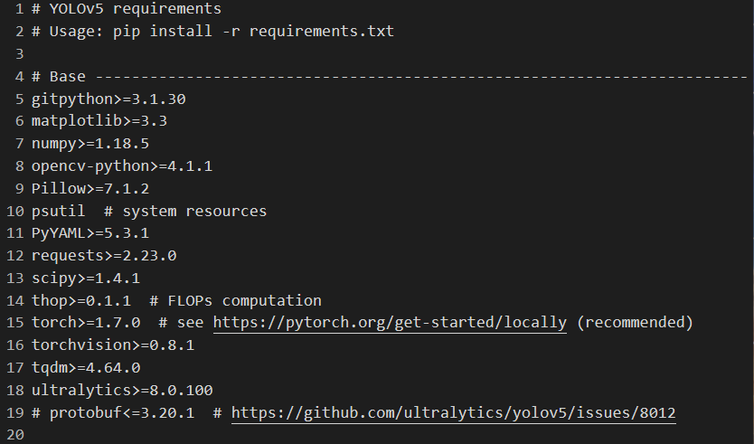

```python
#install further dependencies

!pip install -r requirements.txt
```

```
     ━━━━━━━━━━━━━━━━━━━━━━━━━━━━━━━━━━━━━━ 184.3/184.3 kB 11.1 MB/s eta 0:00:00
     ━━━━━━━━━━━━━━━━━━━━━━━━━━━━━━━━━━━━━━ 591.4/591.4 kB 43.7 MB/s eta 0:00:00
     ━━━━━━━━━━━━━━━━━━━━━━━━━━━━━━━━━━━━━━━━ 62.7/62.7 kB 7.3 MB/s eta 0:00:00
     ━━━━━━━━━━━━━━━━━━━━━━━━━━━━━━━━━━━━━━ 206.5/206.5 kB 25.8 MB/s eta 0:00:00
```

All dependencies have been installed. We can now work on data collection and start making changes to the model as per our requirement/need.

# 2. Data Collection and Preparation

```python
##geting out of the yolov5 folder to our root folder

os.chdir('../')
print(os.getcwd())
```

```
/content/drive/MyDrive/MDA522-Ass2
```

We are now in the root folder.

```python
#making two folders for images and labels

os.mkdir('images')
os.mkdir('labels')
```

```python
#creating train and test sub folders in images and labels folder

#for images

#get into images
os.chdir('images')
#create two sub-folders
os.mkdir('train')
os.mkdir('val')

#get back out of images
os.chdir('../')
#get into labels
os.chdir('labels')

#make two sub-folders
os.mkdir('train')
os.mkdir('val')
```

We now have our folder structure in place.

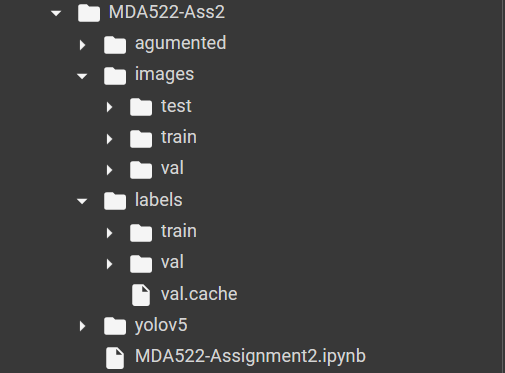

The image/data collection has been discussed in detail in the report. It will not be discussed here.

We will, however, has a look at the code that was used for image agumentation. Image agumentation was done locally on our machine and not Google Colab, so as to generate the pics onto our own machine directly. This is discussed in the report as well.

## 2.1 Image Agumentation

Image agumentation is a technique to increase the number of training samples/images by applying transformation techniques such as cropping, vertical flipping, changing image saturation, change RGB values and so on. In our report, we have used a popular image agumentation library called Albumentations.

```python
!pip install albumentations
```

```python
import albumentations as A
```

```python
#composing a transformation object

transform = A.Compose([
    A.HorizontalFlip(p=0.75), #adds horizontal flip 75% of time
    A.VerticalFlip(p=0.75),   #adds vertical flip 75% of time
    A.RandomRotate90(),       #randomly rotates the img
    A.RandomBrightnessContrast(p=0.25), #random brightness change
    A.RGBShift(p=0.30 ),                #random RGB shift
    A.ColorJitter(contrast=0.5,hue=0.2,always_apply=False,p=0.2),
    A.GaussNoise(p=0.20),               #random noise

    #add random rain effect to mimic real life scenarios
    A.RandomRain(p=0.10,blur_value=4, brightness_coefficient=0.5, rain_type= "drizzle"),

    #add random sun flare effect
    A.RandomSunFlare(p=0.10,num_flare_circles_lower=1,num_flare_circles_upper=4, src_radius=200,always_apply=False),

    #add random shadow effect
    A.RandomShadow(p=0.15,num_shadows_lower=1, num_shadows_upper=3, shadow_dimension=6, always_apply=False)
])

#the transformation model has been composed
```

```python
transform
```

```
Compose([
  HorizontalFlip(always_apply=False, p=0.75),
  VerticalFlip(always_apply=False, p=0.75),
  RandomRotate90(always_apply=False, p=0.5),
  RandomBrightnessContrast(always_apply=False, p=0.25, brightness_limit=(-0.2, 0.2), contrast_limit=(-0.2, 0.2), brightness_by_max=True),
  RGBShift(always_apply=False, p=0.3, r_shift_limit=(-20, 20), g_shift_limit=(-20, 20), b_shift_limit=(-20, 20)),
  ColorJitter(always_apply=False, p=0.2, brightness=[0.8, 1.2], contrast=[0.5, 1.5], saturation=[0.8, 1.2], hue=[-0.2, 0.2]),
  GaussNoise(always_apply=False, p=0.2, var_limit=(10.0, 50.0), per_channel=True, mean=0),
  RandomRain(always_apply=False, p=0.1, slant_lower=-10, slant_upper=10, drop_length=20, drop_width=1, drop_color=(200, 200, 200), blur_value=4, brightness_coefficient=0.5, rain_type='drizzle'),
  RandomSunFlare(always_apply=False, p=0.1, flare_roi=(0, 0, 1, 0.5), angle_lower=0, angle_upper=1, num_flare_circles_lower=1, num_flare_circles_upper=4, src_radius=200, src_color=(255, 255, 255)),
  RandomShadow(always_apply=False, p=0.15, shadow_roi=(0, 0.5, 1, 1), num_shadows_lower=1, num_shadows_upper=3, shadow_dimension=6),
], p=1.0, bbox_params=None, keypoint_params=None, additional_targets={})
```

```python
#helps creating unique id
import uuid


#for following code won't work on Google Colab, it will output error msg here, please ignore
#Img agumentation was done locally


#the following code basically create 10 agumentated images for each image
for i in range(0,10):
    img_name = str(uuid.uuid1())+'.jpg'
    destination = 'agumented/'+img_name
    transformed = transform(image=img)
    img = transformed['image']
    cv2.imwrite(destination, img)
    img_name=''
    img_path=''
```

As mentioned earlier, please ignore the above error message, if any. The code was written to be run locally and not on Google Colab.

The agumented images have been stored in the 'agumented' folder in the root directory.

# 3. Making Changes to the Model Config and Hyperparameters

Yolov5 is one of the most popular models used for object detection. As we are utilizing transfer learning, we would have to make certain changes to the model, especially the model's yaml file.

## 3.1. Creating Custom Configuration YAML File

The yaml files are the configuration files of the model. It contains all the necessary "settings" for the model to work properly.

We'll have to create our very own YAML file.

To do so:

```python
#change working directory to the data folder

os.chdir('/content/drive/MyDrive/MDA522-Ass2/yolov5/data')
```

```python
print(os.getcwd())
```

```
/content/drive/MyDrive/MDA522-Ass2/yolov5/data
```

```python
#once we are within the data sub-folder of Yolov5 we can create the YAML file
import yaml
```

```python
#define a dict to write on the yaml file

custom_dict = [
    #root folder path
    {'path' : '/content/drive/MyDrive/MDA522-Ass2'},

    #training data path relative to root
    {'train' : ['images/train',
                'agumented/images/aadi',
                'agumented/images/ali',
                'agumented/images/bibek',
                'agumented/images/trang']},

    #val or test images path

    {'val' : 'images/val'},

    #classes detail

    {'names' : {0 : 'ied'}}

]
```

```python
custom_dict
```

```
[{'path': '/content/drive/MyDrive/MDA522-Ass2'},
 {'train': ['images/train',
   'agumented/images/aadi',
   'agumented/images/ali',
   'agumented/images/bibek',
   'agumented/images/trang']},
 {'val': 'images/val'},
 {'names': {0: 'ied'}}]
```

```python
#write the YAML file

with open('custom-data.yaml','w') as file:
  wrt = yaml.dump(custom_dict, file)
```

The custom YAML file has been created. The model will now use our dataset to run through the training.

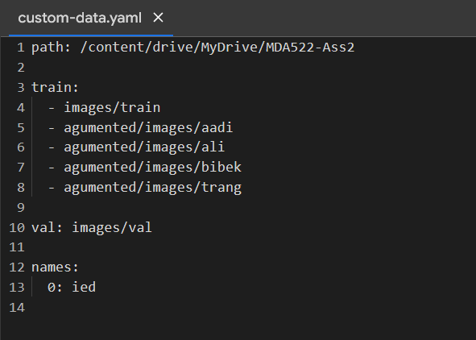

## 3.2. Setting Hyperparameters for training

Before we get onto the training we'll have to set the hyperparameters for the training. The final values of hyperparameters have been chosen after running the model through multiple values of hyperpatameters in the prototype phase.

We'll have to create our custom hyperparameter YAML file.

To do so:

```python
#change directory to the data subfolder of the model

os.chdir('/content/drive/MyDrive/MDA522-Ass2/yolov5/data/hyps')
```

```python
pwd
```

```
'/content/drive/MyDrive/MDA522-Ass2/yolov5/data/hyps'
```

We are now in the hyperpatameter folder of the model. We will first create a dictonary to define all the parameters and then write it as a YAML file like we did previously.

There are around 30 hyperparameters for Yolov5. We have only changed the main ones such as optimizer, learning rate, weight deacy and so on. Every other hyperparameter value is set to default.

```python
#define a dict to write on the yaml file

custom_hyp_dic = [
    {'optimizer':'adam'},
    {'lr0': 0.002},
    {'lrf': 0.01},
    {'momentum': 0.94},
    {'weight_decay': 0.0005},
    {'warmup_epochs': 4.0}
]
```

```python
custom_hyp_dic
```

```
[{'optimizer': 'adam'},
 {'lr0': 0.002},
 {'lrf': 0.01},
 {'momentum': 0.94},
 {'weight_decay': 0.0005},
 {'warmup_epochs': 4.0}]
```

We now have a dictionry for the hyperparameters. We will now write it as a YAML file.

```python
#write the YAML file

with open('custom-hyp.yaml','w') as file:
  wrt = yaml.dump(custom_hyp_dic, file)
```

The file has been created. Further hyperparameters were added onto the file using the default values.

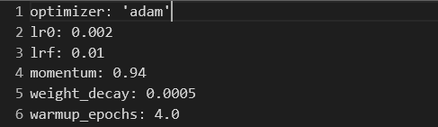

## 3.3. Download Initial Pre-trained Weights

Since we are using Transfer Learning technique, we can utilise pre-trained weights for the model as a starting point. This will significantly reduce the amount of time and resources required for our training. The pre-trained weight can be downloaded from Ultralytics GitHub website.

```python
os.chdir('/content/drive/MyDrive/MDA522-Ass2/yolov5')
```

```python
!pip install wget
```

```
  Preparing metadata (setup.py) ... done
```

```python
import wget

download_url = 'https://github.com/ultralytics/yolov5/releases/download/v5.0/yolov5s.pt'

wget.download(download_url)
```

```
'yolov5s.pt'
```

The file has been downloaded.

Further changes were made to the model, which cannot be shown here but have been discussed in the main report.

# 4. Training the model

Training the model is quite simple.

```python
#change directory to our main yolov5 model folder

os.chdir('/content/drive/MyDrive/MDA522-Ass2/yolov5')
```

```python
!python train.py --batch 50 --epochs 500 --data custom-data.yaml --weights yolov5s.pt --hyp custom-hyp.yaml --workers 6 --cache ram --name b50-e500-run-1 --optimizer Adam
```

[output not shown]

[output cut: 803 more lines]

```
                 Class     Images  Instances          P          R      mAP50   mAP50-95: 100% 2/2 [00:01<00:00,  1.23it/s]
                   all        141        119      0.962       0.95      0.973      0.694
Stopping training early as no improvement observed in last 100 epochs. Best results observed at epoch 57, best model saved as best.pt.
To update EarlyStopping(patience=100) pass a new patience value, i.e. `python train.py --patience 300` or use `--patience 0` to disable EarlyStopping.

158 epochs completed in 1.603 hours.
Optimizer stripped from runs/train/b50-e500-run-1/weights/last.pt, 14.5MB
Optimizer stripped from runs/train/b50-e500-run-1/weights/best.pt, 14.5MB

Validating runs/train/b50-e500-run-1/weights/best.pt...
Fusing layers...
Model summary: 166 layers, 7053910 parameters, 0 gradients
                 Class     Images  Instances          P          R      mAP50   mAP50-95: 100% 2/2 [00:03<00:00,  1.73s/it]
                   all        141        119      0.965       0.95      0.978      0.726
Results saved to runs/train/b50-e500-run-1
```

The model has now been trained. The results of the model, along with the weights have been saved to the **runs/train/b50-e500-run-1** folder.

# 5. Model Validation and Visualisation

Validation happens after every epoch. However, validation can also be run manually using the following piece of code.

```python
trained_model_path = '/content/drive/MyDrive/MDA522-Ass2/yolov5/runs/train/b50-e500-run-1'
best_train_weight = '/content/drive/MyDrive/MDA522-Ass2/yolov5/runs/train/b50-e500-run-1/weights/best.pt'
last_train_weight = '/content/drive/MyDrive/MDA522-Ass2/yolov5/runs/train/b50-e500-run-1/weights/last.pt'
```

```python
!python val.py --batch=40 --weights best_train_weight --data custom-data.yaml
```

We can also visualise the progress of the model.

```python
from utils.plots import plot_results

result_csv_path = '/content/drive/MyDrive/MDA522-Ass2/yolov5/runs/train/b50-e500-run-1/results.csv'

plot_results(result_csv_path)
```

```python
vis_path = "/content/drive/MyDrive/MDA522-Ass2/yolov5/runs/train/b50-e500-run-1/results.png"
```

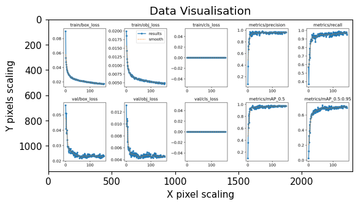

```python
from matplotlib import image as mpimg

%matplotlib inline
plt.title("Data Visualisation")
plt.xlabel("X pixel scaling")
plt.ylabel("Y pixels scaling")

image = mpimg.imread(vis_path)
plt.imshow(image)
plt.show()
```

# 6. Prediction

```python
#load our custom model from trained folder path

#model path
trained_model_path = best_train_weight

#load model
model = torch.hub.load('ultralytics/yolov5', 'custom', path=trained_model_path, force_reload=True)
```

```python
#define function for title and subtitle for the plots
#this will later be used in the plot

def get_title(num):
  if num == 0:
    return 'Real Waste'
  else:
    return 'IED Detected'
```

```python
def get_subtitle(num):
  if num == 0:
    return 'No IED'
  else:
    return 'No of IED detected: ' + str(num)
```

## 6.1. Multiple predictions at once

There is a folder called 'test' that contains images that have not been used in the training or the validation of the model. The images are completely unseen by the model. We will do our prediction to those images.

```python
#test imgs path

test_img_path = '/content/drive/MyDrive/MDA522-Ass2/images/test'
```

```python
#define a function to load all images from a specific folder


def load_images_from_folder(folder):
    images = []
    for filename in os.listdir(folder):
        img = cv2.imread(os.path.join(folder,filename))
        if img is not None:
            images.append(img)
    return images

#function list of all images from the folder
```

```python
#create a list for test images

test_imgs=[]
test_imgs = load_images_from_folder(test_img_path)
len(test_imgs)
```

```
12
```

As we can see, we have 12 test images. These images have not been exposed to the model at all.

```python
#create a list to store all the predicted result from the test
results = []

#loops through each image in the test img list
for img in test_imgs:
  preidcted = model(img)  #does prediction for each img at a time

  #adds prediction to the results list
  results.append(preidcted)

len(results)
```

```
12
```

The model has done prediction for all 12 of the test images. Now let's plot them.

[figure not shown]

```python
%matplotlib inline

#define rows and columns for the prediction plot
rows = 3
column = 4

#set size
fig = plt.figure(figsize=(20, 10))

i = 1

#loops through each prediction and plots in a 3x4 grid


for result in results:
  num_ied = len(result.pandas().xyxy[0])

  fig.add_subplot(rows, column, i)
  img = np.squeeze(result.render())
  img = cv2.cvtColor(img, cv2.COLOR_BGR2RGB)
  plt.title(get_title(num_ied),loc='center', c='red', weight='bold', pad=5)
  plt.ylabel(get_subtitle(num_ied))
  plt.imshow(img)
  i += 1

  #if no. of test images is more than 12 the loop breaks as our plot can only handle
  #3x4 = 12 charts
  if i >= 13:
    break

plt.show()
```

## 6.2. Single Image Prediction

```python
#image path for prediction
#one image at a time

img_path_test = '/content/drive/MyDrive/MDA522-Ass2/images/val/IMG_6650.JPG'
```

```python
#run it through the model
prediction = model(img_path_test)
num_ied = len(prediction.pandas().xyxy[0])
```

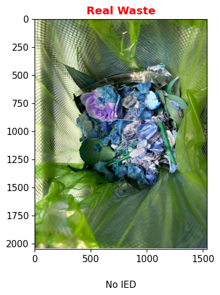

```python
#finally plotting the prediction

%matplotlib inline

#set size
fig = plt.figure(figsize=(5, 5))

img = np.squeeze(prediction.render())
img = cv2.cvtColor(img, cv2.COLOR_BGR2RGB)

plt.imshow(img)
plt.title(get_title(num_ied),loc='center', c='red', weight='bold')
plt.xlabel(get_subtitle(num_ied), labelpad=20)
plt.show()
```